# Two-Way ANOVA project

## Collaboration rules:

You may consult with up to two classmates for help with this project, but use your own data. Please identify who you collaborate with here.

**Response:**

# Instructions

Write a report that includes an introduction to the data, appropriate EDA, model specification, the checking of conditions, and in context conclusions. To include sections in your report use the # as illustrated by the # Instructions for this section. Larger section headings have one #, smaller subsection headings have ## or ### or even ####. There should be a coherent and well-organized narrative in addition to appropriate code and figures.

# Car data

The dataset contains the Price, mileage and year of 3 different types of cars (BMW X3, Honda civic, Ford Taurus) at two different locations (20010 & 90095)

## EDA

### Read in the data and report the mean and standard deviation

```r
library(readr)
cars <- read_csv("datacarrevise.csv")
cars
```

```
## # A tibble: 300 x 5
##     year price mileage zipcode model
##    <dbl> <dbl>   <dbl>   <dbl> <chr>
##  1  2018  30.9    31.5   20010 BMW X3
##  2  2017  24.9    24.7   20010 BMW X3
##  3  2019  28.6    20.7   20010 BMW X3
##  4  2016  19.7    50.9   20010 BMW X3
##  5  2017  25.8    30.4   20010 BMW X3
##  6  2017  24.7    34.8   20010 BMW X3
##  7  2016  19.7    37.7   20010 BMW X3
##  8  2019  48.0    14.2   20010 BMW X3
##  9  2019  52.4    11.2   20010 BMW X3
## 10  2017  27.6    25.0   20010 BMW X3
## # ... with 290 more rows
```

```r
cars2 <- cars%>%
  mutate( zipcode = as.character(zipcode))%>%
  group_by(zipcode, model)%>%
  summarise(mean = mean(price), sd = sd(price))
cars2
```

```
## # A tibble: 6 x 4
## # Groups:   zipcode [2]
##   zipcode model        mean    sd
##   <chr>   <chr>       <dbl> <dbl>
## 1 20010   BMW X3       26.9  9.04
## 2 20010   Ford Taurus  14.0  5.65
## 3 20010   Honda Civic  17.6  6.02
## 4 90095   BMW X3       24.4  4.54
## 5 90095   Ford Taurus  14.1  3.40
## 6 90095   Honda Civic  17.8  3.37
```

It seems like thare is aproblem with standard deviation variabilty because 9.044/3.373 > 2

### side-by-side dotplot

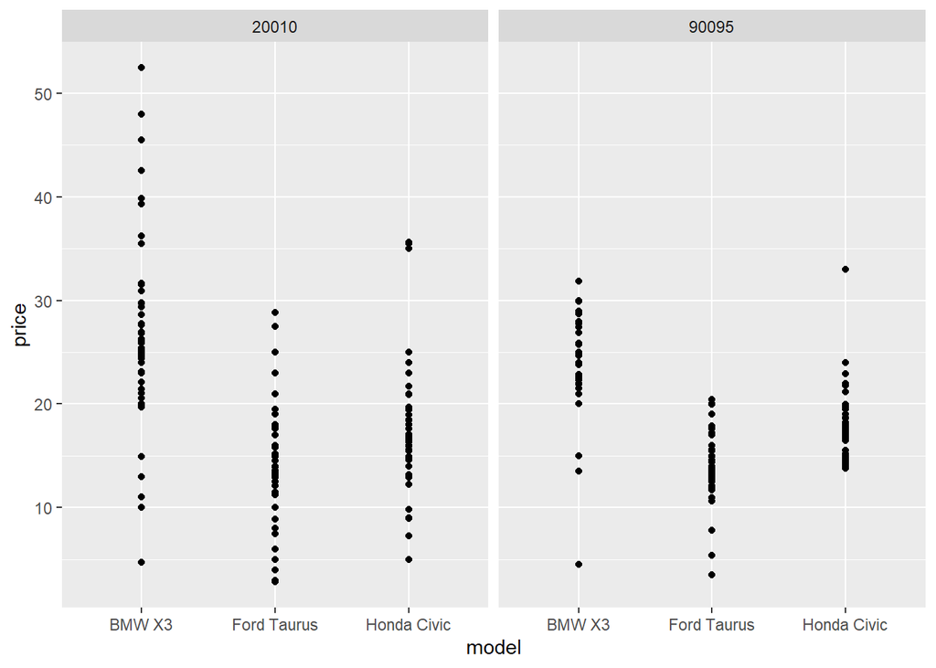

```r
gf_point(price~model | zipcode, data = cars)
```

From the dot plot, it seems like BMW X3C has the highest price compared to the other 2 models but price is higher for 20010 zipcode. For the other two models, it seems like there’s not much of a different in price between the 20020 and 90095 zipcode but 20010 has more variability.

### Interaction plot

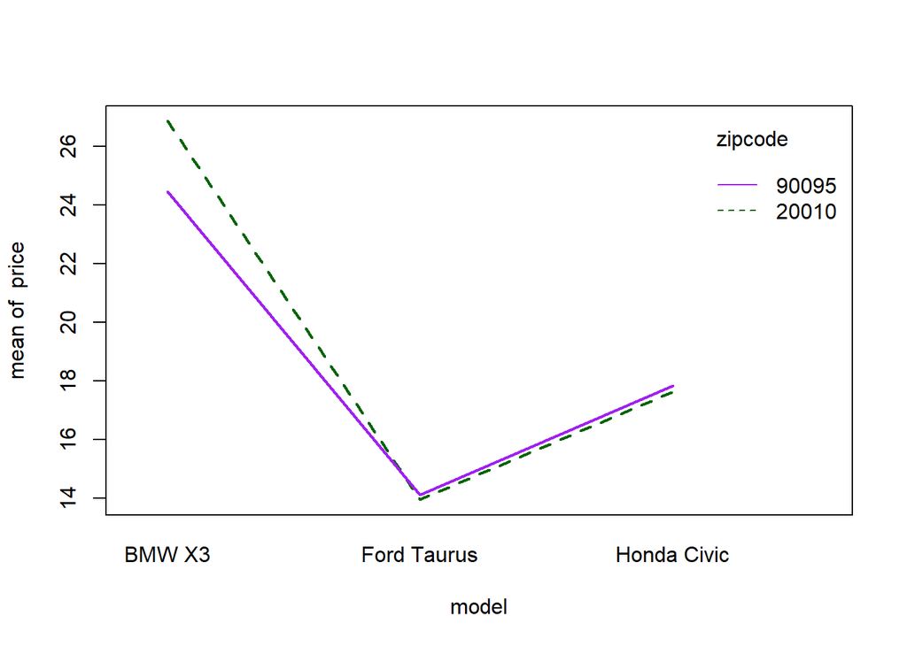

```r
with(cars, interaction.plot(model, zipcode, price, lwd = 2, col = c("darkgreen", "purple")))
```

From the interaction plot, BMW X3 has the highest mean price for both location while Ford Taurus has the lowest price. The pattern of the two lines are similar with the first line has a bit different slope but the difference is not that big so I would say that they do have a parallel slope hence no important interaction presence.